# Diagnosing Schizophrenia from Voice

Barbora Ferusová - (barbora.ferusova@gmail.com)

Last edited: 2024-03-20

### **Skills Showcased:**

- **Advanced Data Manipulation:** Proficiency in transforming and preparing large datasets for analysis using R.
- **Statistical Analysis:** Expertise in conducting descriptive statistical analyses to understand data characteristics and underlying patterns.
- **Machine Learning:** Advanced skills in building and optimizing machine learning models, including random forests and support vector machines.
- **Data Visualization:** Competence in creating insightful visual representations of data and model performance metrics.
- **Feature Engineering and Model Tuning:** Ability to enhance model performance through systematic feature engineering and hyperparameter tuning.

# Introduction to the project

This project draws inspiration from the cutting-edge research outlined in “Voice Patterns as Markers of Schizophrenia” (Parola A et al., 2023), which posits the utility of vocal characteristics in diagnosing schizophrenia. Leveraging advanced analytical techniques, this study aims to discern the potential of voice atypicalities as biomarkers for schizophrenia, emphasizing their relevance in cognitive and social dynamics of the disorder. The goal is to employ sophisticated unsupervised and supervised learning methods to ascertain if schizophrenia can be accurately diagnosed through vocal features.

1. Collecting and cleaning the project data
2. Understanding the data using descriptive statistics
3. Predicting diagnosis using supervised learning procedures
4. Discussion on the methods and the results

# Collecting and cleaning the data

## Introduction to datasets:

1. **articulation_data.txt**. This file contains all duration-related data collected from the participants to the different studies included in the project. Here is a short description of its linguistic variables.
- *nsyll:* number of syllables automatically inferred from the audio
- *npause:* number of pauses automatically inferred from the audio (absence of human voice longer than 200 milliseconds)
- *dur (s):* duration (in seconds) of the full recording
- *phonationtime (s):* duration (in seconds) of the recording where speech is present
- *speechrate (nsyll/dur):* average number of syllables per second
- *articulation rate (nsyll/phonationtime):* average number of syllables per second where speech is present

```r
articulation <- read_tsv("data/articulation_data.tsv") %>% rename(Study = study, ID = id, Diagnosis = diagnosis, Trial = trial)
articulation
```

```
## # A tibble: 1,900 × 13
##    Study    ID Diagnosis Trial duration phonation_duration pause_duration
##    <dbl> <dbl> <chr>     <dbl>    <dbl>              <dbl>          <dbl>
##  1     1   101 control       1     3.6                2.24           1.36
##  2     1   101 control      10     2.2                1.46           0.74
##  3     1   101 control       2     9                  3.33           5.67
##  4     1   101 control       3     6.08               4.18           1.9
##  5     1   101 control       4     9.57               5.46           4.11
##  6     1   101 control       5    12.7                6.56           6.14
##  7     1   101 control       6     5.28               3.58           1.7
##  8     1   101 control       7     5.7                3.22           2.48
##  9     1   101 control       8     2.9                1.42           1.48
## 10     1   101 control       9    10.5                6.69           3.84
## # ℹ 1,890 more rows
## # ℹ 6 more variables: n_syllables <dbl>, n_pauses <dbl>,
## #   `speech_rate (n_syllables/duration)` <dbl>,
## #   `articulation_rate (n_syllables/phonation_duration)` <dbl>,
## #   average_syllable_duration <dbl>, average_pause_duration <dbl>
```

2. **pitch_data.txt**. Aggregated pitch data collected from the participants to the different studies included in the project. Fundamental pitch frequency was recorded for each participant every 10 milliseconds (excluding pauses) and aggregated at the participant trial level with the use of various centrality and dispersion measures.
- *iqr:* Interquartile range
- *mad:* Mean absolute deviation
- *coefvar:* Coefficient of variation

```r
pitch <- read_tsv("data/pitch_data.tsv")
pitch
```

```
## # A tibble: 1,900 × 12
##    Study Diagnosis    ID Trial  mean    sd   min   max median   iqr   mad
##    <dbl> <chr>     <dbl> <dbl> <dbl> <dbl> <dbl> <dbl>  <dbl> <dbl> <dbl>
##  1     1 control     101     1  133. 21.9  106.   212.   124. 35.2  17.3
##  2     1 control     101    10  132.  6.83  98.3  143.   133.  8.13  5.91
##  3     1 control     101     2  133. 18.2  114.   240.   129. 14.9  10.5
##  4     1 control     101     3  122. 12.2   90.8  210.   123.  6.66  4.88
##  5     1 control     101     4  125.  9.10  95.9  178.   124. 12.7   9.38
##  6     1 control     101     5  131. 21.5   90.4  242.   128. 14.2  10.4
##  7     1 control     101     6  131. 25.6   90.3  246.   123. 22.2  15.0
##  8     1 control     101     7  157. 36.7  101    241.   144. 61.1  33.7
##  9     1 control     101     8  116.  4.97 105.   130.   116.  7.01  5.03
## 10     1 control     101     9  130. 19.7   93.8  221.   128. 24.4  18.8
## # ℹ 1,890 more rows
## # ℹ 1 more variable: coefvar <dbl>
```

- renaming variables to prepare for merging datasets:

```r
dataset <- left_join(articulation, pitch, by = c("Study", "Trial", "ID", "Diagnosis")) %>%
  rename(
    rate_of_speech = "speech_rate (n_syllables/duration)",
    rate_of_articulation = "articulation_rate (n_syllables/phonation_duration)",
    mean_pause_duration = average_pause_duration,
    pitch_mean = mean,
    pitch_sd = sd,
    pitch_min = min,
    pitch_max = max,
    pitch_median = median,
    pitch_iqr = iqr,
    pitch_mad = mad,
    pitch_CV = coefvar
  ) %>%
  mutate_at(c("Study", "Trial", "ID"), factor) %>%
  mutate(
    Diagnosis = factor(Diagnosis, levels = c("schizophrenia", "control")),
    ID = paste0(ID, Diagnosis),
    mean_pause_duration = replace_na(mean_pause_duration, mean(mean_pause_duration, na.rm = TRUE)),
    n_pauses = replace_na(n_pauses, median(n_pauses, na.rm = TRUE))
  )

dataset
```

```
## # A tibble: 1,900 × 21
##    Study ID         Diagnosis Trial duration phonation_duration pause_duration
##    <fct> <chr>      <fct>     <fct>    <dbl>              <dbl>          <dbl>
##  1 1     101control control   1         3.6                2.24           1.36
##  2 1     101control control   10        2.2                1.46           0.74
##  3 1     101control control   2         9                  3.33           5.67
##  4 1     101control control   3         6.08               4.18           1.9
##  5 1     101control control   4         9.57               5.46           4.11
##  6 1     101control control   5        12.7                6.56           6.14
##  7 1     101control control   6         5.28               3.58           1.7
##  8 1     101control control   7         5.7                3.22           2.48
##  9 1     101control control   8         2.9                1.42           1.48
## 10 1     101control control   9        10.5                6.69           3.84
## # ℹ 1,890 more rows
## # ℹ 14 more variables: n_syllables <dbl>, n_pauses <dbl>, rate_of_speech <dbl>,
## #   rate_of_articulation <dbl>, average_syllable_duration <dbl>,
## #   mean_pause_duration <dbl>, pitch_mean <dbl>, pitch_sd <dbl>,
## #   pitch_min <dbl>, pitch_max <dbl>, pitch_median <dbl>, pitch_iqr <dbl>,
## #   pitch_mad <dbl>, pitch_CV <dbl>
```

```r
write_tsv(dataset, "data/dataset_clean.tsv")
```

# Understanding the sample using descriptive statistics

> The groups seem reasonably balanced across diagnoses, though controls are slightly overrepresented.

```r
datasummary(
  data = dataset,
  formula = Diagnosis * Study ~ (N + Percent()),
  type = "categorical",
  output = "data.frame",
  fmt = fmt_sprintf("%.1f")
) %>% rename(Proportion = Percent)
```

```
##       Diagnosis Study   N Proportion
## 1 schizophrenia     1 335       17.6
## 2                   2 179        9.4
## 3                   3 151        7.9
## 4                   4 238       12.5
## 5       control     1 348       18.3
## 6                   2 184        9.7
## 7                   3 232       12.2
## 8                   4 233       12.3
```

- Describing the acoustic profile of a schizophrenic voice: which features are different? E.g. People with schizophrenia tend to have high-pitched voice.

> A number of features seem to differ between the groups, though large amounts of within-group deviation makes it hard to assess whether these disparities are due to noise. `rate_of_speech` and. rate_of_articulation`, seem promising, both having low coefficients of variance and disparity in mean values.

```r
coefvar <- function(vals) sd(vals, na.rm = TRUE) / mean(vals, na.rm = TRUE)

datasummary(
  data = dataset,
  formula = All(dataset) * Diagnosis ~ (mean + sd + coefvar),
  type = "categorical",
  output = "data.frame",
  fmt = fmt_sprintf("%.1f")
)
```

```
##                                  Diagnosis  mean    sd coefvar
## 1                   duration schizophrenia  17.6  16.8     1.0
## 2                                  control  18.7  12.8     0.7
## 3         phonation_duration schizophrenia  10.4   9.4     0.9
## 4                                  control  12.2   9.5     0.8
## 5             pause_duration schizophrenia   7.3   9.1     1.2
## 6                                  control   6.5   4.8     0.7
## 7                n_syllables schizophrenia  50.3  47.0     0.9
## 8                                  control  60.8  46.8     0.8
## 9                   n_pauses schizophrenia   8.0   8.3     1.0
## 10                                 control   8.1   6.2     0.8
## 11            rate_of_speech schizophrenia   2.9   0.9     0.3
## 12                                 control   3.2   0.7     0.2
## 13      rate_of_articulation schizophrenia   4.8   0.8     0.2
## 14                                 control   5.0   0.7     0.1
```

[output cut: 20 more lines]

# Predicting diagnosis using supervised learning procedures

Here I want to see if I can automatically diagnose schizophrenia from voice alone. To do this, I will proceed in incremental fashion. I will first start by building a simple random forest model, add an optimized version, and then add a third model based on an algorithm I see best fit for this purpose.

The following packages will be used:

```r
pacman::p_load(
  tidymodels,
  rsample,
  parsnip,
  randomForest,
  kernlab,
  yardstick,
  recipes,
  workflows,
  vip
)
```

## First phase: Random Forest Model

Developing a Random Forest classifier, training it on a curated dataset to establish a baseline for diagnostic accuracy.

- Splitting the data in training and testing sets

```r
dataset_split <- initial_split(
  dataset,
  prop = 0.7,
  strata = Diagnosis
)

training(dataset_split)
```

```
## # A tibble: 1,329 × 21
##    Study ID         Diagnosis Trial duration phonation_duration pause_duration
##    <fct> <chr>      <fct>     <fct>    <dbl>              <dbl>          <dbl>
##  1 1     101control control   10        2.2                1.46           0.74
##  2 1     101control control   5        12.7                6.56           6.14
##  3 1     101control control   8         2.9                1.42           1.48
##  4 1     101control control   9        10.5                6.69           3.84
##  5 1     102control control   10        5.89               4.06           1.83
##  6 1     102control control   2        14.4                9.22           5.14
##  7 1     102control control   4        15.7               11.6            4.16
##  8 1     102control control   5         6.6                5.14           1.46
##  9 1     102control control   6         9.14               6.59           2.55
## 10 1     102control control   7        13                  8.99           4.01
## # ℹ 1,319 more rows
## # ℹ 14 more variables: n_syllables <dbl>, n_pauses <dbl>, rate_of_speech <dbl>,
## #   rate_of_articulation <dbl>, average_syllable_duration <dbl>,
## #   mean_pause_duration <dbl>, pitch_mean <dbl>, pitch_sd <dbl>,
## #   pitch_min <dbl>, pitch_max <dbl>, pitch_median <dbl>, pitch_iqr <dbl>,
## #   pitch_mad <dbl>, pitch_CV <dbl>
```

- Training a random forest model on the training set

```r
modelling_recipe <- recipe(Diagnosis ~ ., data = training(dataset_split)) %>%
  update_role(ID, new_role = "Participant ID") %>%
  update_role(Study, Trial, new_role = "Metadata") %>%
  update_role(pitch_median, pitch_mad, pitch_sd, pitch_iqr, new_role = "Collinear") # eliminating a number of multicollinear features

rf_workflow <- workflow() %>%
  add_model(rand_forest(mode = "classification", engine = "randomForest")) %>%
  add_recipe(modelling_recipe)

rf_fit <- rf_workflow %>% fit(training(dataset_split))
rf_fit
```

```
## ══ Workflow [trained] ══════════════════════════════════════════════════════════
## Preprocessor: Recipe
## Model: rand_forest()
##
## ── Preprocessor ────────────────────────────────────────────────────────────────
## 0 Recipe Steps
##
## ── Model ───────────────────────────────────────────────────────────────────────
##
## Call:
##  randomForest(x = maybe_data_frame(x), y = y)
##                Type of random forest: classification
##                      Number of trees: 500
## No. of variables tried at each split: 3
##
##         OOB estimate of  error rate: 35.74%
## Confusion matrix:
##               schizophrenia control class.error
## schizophrenia           387     245   0.3876582
## control                 230     467   0.3299857
```

- Testing the model’s predictions on the testing set

```r
predicted <- testing(dataset_split) %>%
  mutate(
    Predicted = predict(rf_fit, new_data = testing(dataset_split))$.pred_class,
    Prob_Control = predict(rf_fit, new_data = testing(dataset_split), type = "prob")$.pred_control %>% round(2)
  )
predicted %>% select(Diagnosis, Predicted, Prob_Control)
```

```
## # A tibble: 571 × 3
##    Diagnosis Predicted     Prob_Control
##    <fct>     <fct>                <dbl>
##  1 control   schizophrenia         0.46
##  2 control   control               0.55
##  3 control   control               0.63
##  4 control   schizophrenia         0.45
##  5 control   schizophrenia         0.42
##  6 control   schizophrenia         0.48
##  7 control   control               0.53
##  8 control   schizophrenia         0.42
##  9 control   schizophrenia         0.45
## 10 control   schizophrenia         0.36
## # ℹ 561 more rows
```

- Building the confusion matrix

```r
conf_mat(
  predicted,
  truth = Diagnosis,
  estimate = Predicted
)
```

```
##                Truth
## Prediction      schizophrenia control
##   schizophrenia           177     104
##   control                  94     196
```

- Compiling performance metrics.

```r
selected_performance_metrics <- metric_set(accuracy, sens, spec, mcc, roc_auc, pr_auc)

selected_performance_metrics(
  predicted,
  truth = Diagnosis,
  estimate = Predicted,
  Prob_Control
) %>%
  select(c(.metric, .estimate)) %>%
  column_to_rownames(".metric") %>%
  round(2)
```

```
##          .estimate
## accuracy      0.65
## sens          0.65
## spec          0.65
## mcc           0.31
## roc_auc       0.29
## pr_auc        0.35
```

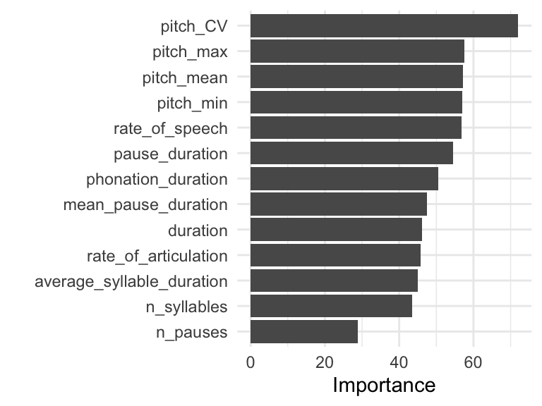

```r
rf_fit %>% extract_fit_parsnip() %>% vip(num_features = ncol(dataset_split) - 1)
```

## Second phase: Forest Engineering

Enhancing the Random Forest model through feature normalization and hyperparameter tuning, aiming to refine predictive performance.

```r
dataset_split <- initial_validation_split(
  dataset,
  prop = c(0.7, 0.15),
  strata = Diagnosis
)

modelling_recipe <- modelling_recipe %>%
  step_normalize(all_numeric_predictors(), -starts_with("n_"), -all_outcomes()) %>%
  step_naomit(n_pauses)

rf_workflow_tune <- workflow() %>%
  add_model(rand_forest(
    mode = "classification",
    engine = "randomForest",
    trees = tune(),
    min_n = tune()
  )) %>%
  add_recipe(modelling_recipe)

tripartite_rf_results <- tune_grid(
  rf_workflow_tune,
  vfold_cv(validation(dataset_split)),
  grid = grid_max_entropy(extract_parameter_set_dials(rf_workflow_tune), size = 10)
)
tripartite_rf_results %>% collect_metrics()
```

```
## # A tibble: 20 × 8
##    trees min_n .metric  .estimator  mean     n std_err .config
##    <int> <int> <chr>    <chr>      <dbl> <int>   <dbl> <chr>
##  1   321    25 accuracy binary     0.658    10  0.0194 Preprocessor1_Model01
##  2   321    25 roc_auc  binary     0.681    10  0.0237 Preprocessor1_Model01
##  3  1082    38 accuracy binary     0.655    10  0.0127 Preprocessor1_Model02
##  4  1082    38 roc_auc  binary     0.681    10  0.0214 Preprocessor1_Model02
##  5    52    39 accuracy binary     0.641    10  0.0165 Preprocessor1_Model03
##  6    52    39 roc_auc  binary     0.695    10  0.0216 Preprocessor1_Model03
##  7  1977    40 accuracy binary     0.662    10  0.0151 Preprocessor1_Model04
##  8  1977    40 roc_auc  binary     0.684    10  0.0223 Preprocessor1_Model04
##  9  1871    15 accuracy binary     0.651    10  0.0204 Preprocessor1_Model05
## 10  1871    15 roc_auc  binary     0.670    10  0.0220 Preprocessor1_Model05
## 11  1055    18 accuracy binary     0.651    10  0.0174 Preprocessor1_Model06
## 12  1055    18 roc_auc  binary     0.678    10  0.0224 Preprocessor1_Model06
## 13  1610    28 accuracy binary     0.662    10  0.0179 Preprocessor1_Model07
## 14  1610    28 roc_auc  binary     0.682    10  0.0247 Preprocessor1_Model07
## 15   319    11 accuracy binary     0.658    10  0.0179 Preprocessor1_Model08
## 16   319    11 roc_auc  binary     0.669    10  0.0204 Preprocessor1_Model08
## 17  1535     3 accuracy binary     0.637    10  0.0147 Preprocessor1_Model09
## 18  1535     3 roc_auc  binary     0.678    10  0.0200 Preprocessor1_Model09
## 19   697     2 accuracy binary     0.658    10  0.0174 Preprocessor1_Model10
## 20   697     2 roc_auc  binary     0.676    10  0.0219 Preprocessor1_Model10
```

```r
selected_fit <- last_fit(
  finalize_workflow(rf_workflow_tune, select_best(tripartite_rf_results, "roc_auc")),
  dataset_split,
  add_validation_set = FALSE
)

predicted <- testing(dataset_split) %>%
  mutate(
    Predicted = collect_predictions(selected_fit, new_data = testing(dataset_split))$.pred_class,
    Prob_Control = collect_predictions(selected_fit, new_data = testing(dataset_split), type = "prob")$.pred_control %>%
      round(2)
  )
```

```r
conf_mat(
  predicted,
  truth = Diagnosis,
  estimate = Predicted
)
```

```
##                Truth
## Prediction      schizophrenia control
##   schizophrenia            84      61
##   control                  52      90
```

```r
selected_performance_metrics(
  predicted,
  truth = Diagnosis,
  estimate = Predicted,
  Prob_Control
) %>%
  select(c(.metric, .estimate)) %>%
  column_to_rownames(".metric") %>%
  round(2)
```

```
##          .estimate
## accuracy      0.61
## sens          0.62
## spec          0.60
## mcc           0.21
## roc_auc       0.31
## pr_auc        0.36
```

```r
model_metrics <- bind_rows(
selected_performance_metrics(
    collect_predictions(last_fit(rf_workflow, dataset_split, add_validation_set = FALSE)),
    truth = Diagnosis,
    estimate = .pred_class,
    .pred_control
  ) %>% mutate(model = factor("Default Random Forest")),
selected_performance_metrics(
    collect_predictions(selected_fit),
    truth = Diagnosis,
    estimate = .pred_class,
    .pred_control
  ) %>% mutate(
    model = factor("Hyperparameter tuning, normalization")
  )
) %>%
  mutate(.metric = factor(.metric, ordered = TRUE)) %>%
  select(!.estimator)

model_metrics
```

```
## # A tibble: 12 × 3
##    .metric  .estimate model
##    <ord>        <dbl> <fct>
##  1 accuracy     0.613 Default Random Forest
##  2 sens         0.596 Default Random Forest
##  3 spec         0.629 Default Random Forest
##  4 mcc          0.225 Default Random Forest
##  5 roc_auc      0.332 Default Random Forest
##  6 pr_auc       0.368 Default Random Forest
##  7 accuracy     0.606 Hyperparameter tuning, normalization
##  8 sens         0.618 Hyperparameter tuning, normalization
##  9 spec         0.596 Hyperparameter tuning, normalization
## 10 mcc          0.213 Hyperparameter tuning, normalization
## 11 roc_auc      0.309 Hyperparameter tuning, normalization
## 12 pr_auc       0.364 Hyperparameter tuning, normalization
```

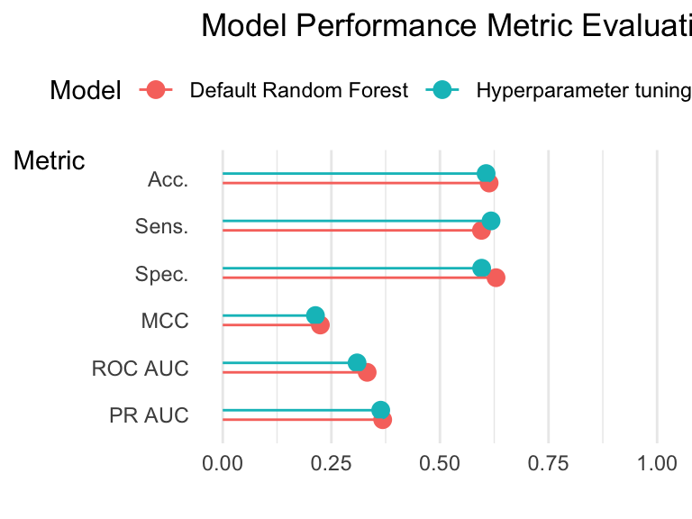

```r
ggplot(model_metrics) +
  geom_point(aes(.estimate, .metric, color = model), position = position_dodge(width = 0.4), size = 3) +
  geom_linerange(aes(xmin = 0, xmax = .estimate, y = .metric, color = model), position = position_dodge(width = 0.4)) +
  coord_cartesian(xlim = c(0, 1)) +
  scale_y_discrete(
    limits = rev(c("accuracy", "sens", "spec", "mcc", "roc_auc", "pr_auc")),
    labels = rev(c("Acc.", "Sens.", "Spec.", "MCC", "ROC AUC", "PR AUC"))
  ) +
  labs(title = "Model Performance Metric Evaluation", x = "", y = "Metric\n", ) +
  theme(legend.position = "top", panel.grid.major.y = element_blank(), axis.title.y = element_text(angle=0, vjust=1)) +
  guides(color = guide_legend(title = "Model"))
```

## Third phase: Another Algorithm

```r
rf_workflow_svm <- workflow() %>%
  add_model(svm_poly(
    mode = "classification",
    engine = "kernlab"
  )) %>%
  add_recipe(modelling_recipe)

rf_fit <- rf_workflow_svm %>% fit(training(dataset_split))
model_metrics <- bind_rows(
selected_performance_metrics(
    collect_predictions(last_fit(rf_workflow, dataset_split, add_validation_set = FALSE)),
    truth = Diagnosis,
    estimate = .pred_class,
    .pred_control
  ) %>% mutate(model = factor("Default Random Forest")),
selected_performance_metrics(
    collect_predictions(selected_fit),
    truth = Diagnosis,
    estimate = .pred_class,
    .pred_control
  ) %>% mutate(
    model = factor("Support Vector Machine")
  )
) %>%
  mutate(.metric = factor(.metric, ordered = TRUE)) %>%
  select(!.estimator)
model_metrics
```

[output not shown]

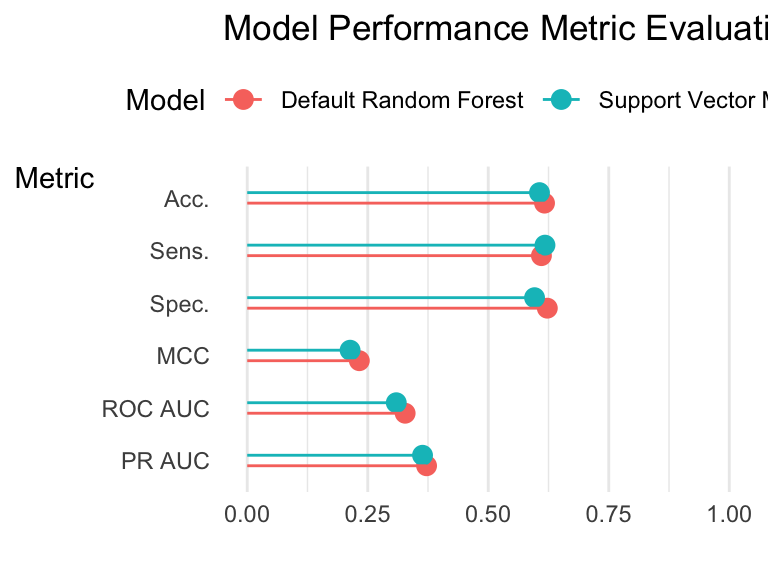

```r
ggplot(model_metrics) +
  geom_point(aes(.estimate, .metric, color = model), position = position_dodge(width = 0.4), size = 3) +
  geom_linerange(aes(xmin = 0, xmax = .estimate, y = .metric, color = model), position = position_dodge(width = 0.4)) +
  coord_cartesian(xlim = c(0, 1)) +
  scale_y_discrete(
    limits = rev(c("accuracy", "sens", "spec", "mcc", "roc_auc", "pr_auc")),
    labels = rev(c("Acc.", "Sens.", "Spec.", "MCC", "ROC AUC", "PR AUC"))
  ) +
  labs(title = "Model Performance Metric Evaluation", x = "", y = "Metric\n", ) +
  theme(legend.position = "top", panel.grid.major.y = element_blank(), axis.title.y = element_text(angle=0, vjust=1)) +
  guides(color = guide_legend(title = "Model"))
```

# Discussion: Methodology and Results

Reflecting on the nuanced interplay between feature engineering, model complexity, and diagnostic accuracy, highlighting the challenges and potential of using vocal characteristics in schizophrenia diagnosis.

> The feature engineering and hyperparameter tuning did not seem to noticably improve the performance of the classfication model. In fact, when it marginally improves on the default model in one metric, e.g. sensitivity, it tends to sacrifice/worsen others. None of the models were particularly useful in a clinical context (at least as stand-alone tool), as they failed to improve more than moderately on the baseline accuracy of ~50%, with all models maxing out around 65%.

> The actual baseline accuracy for this dataset might be 52.5%, as this is the accuracy that would be achieved if one just predicted “control” for all cases, although that would reveal itself in disparity between sensitivity and specificity.

> One could make a cautious interpretation that trends in voice pitch should be ascribed greater weight than other more basic measures of articulation.